# STAT 118: Homework F

Customizing Plots: `scales`, labels, `facet_wrap()`

Author

```r
# load packages
library(tidyverse)
# load data
library(gapminder)
library(scales)
library(ggrepel)
data(gapminder)
```

# 1. Gapminder Scatterplot

- For the year 2007, plot GDP per capita (x-axis) vs. life expectancy (y-axis).
- Format large numbers as numbers with commas (not scientific notation)
- color points by continent
- Be sure your axes are clearly labelled for a general audience

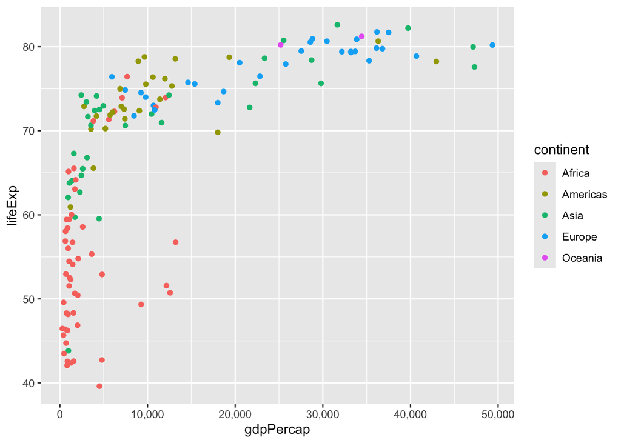

```r
gapminder |>
  filter(year==2007) |>
ggplot(aes(x=gdpPercap, y=lifeExp)) +
  geom_point(aes(color=continent)) +
  scale_x_continuous(labels=label_comma())
```

# 2. Log-Transformed Gapminder Scatterplot

Take your scatterplot from the previous problem. Log-transform the GDP per capita axis. Explain why a log-transformed x-axis is useful here.

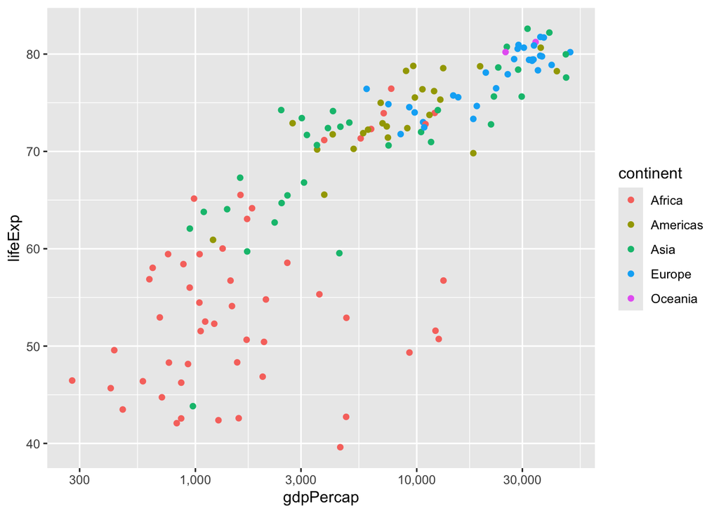

```r
gapminder |>
  filter(year==2007) |>
ggplot(aes(x=gdpPercap, y=lifeExp)) +
  geom_point(aes(color=continent)) +
  scale_x_log10(labels=label_comma())
```

# 3. Gapminder Scatterplot with labels

Take your scatterplot from the previous problem. Use `geom_text_repel()` to label the subset of countries which have a GDP per capita over over $40,000.

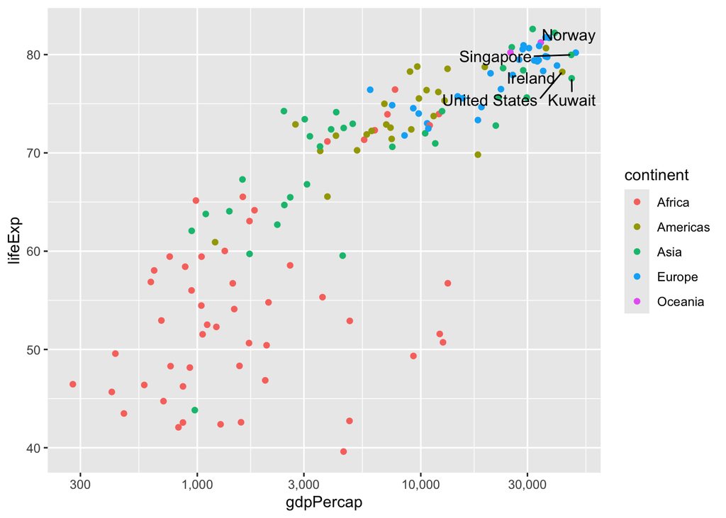

```r
gapminder |>
  filter(year==2007) |>
  mutate(high_gdp=case_when(gdpPercap > 40000 ~ country,
                            TRUE ~ NA)) |>
ggplot(aes(x=gdpPercap, y=lifeExp)) +
  geom_point(aes(color=continent)) +
  geom_text_repel(aes(label=high_gdp)) +
  scale_x_log10(labels=label_comma())
```

# 4. Gapminder Scatterplot over the years

Repeat your plot for #2 for all years in the dataset. Hint: you’ll need to make sure you are using the full dataset for all years (not just 2007 like in the previous plots).

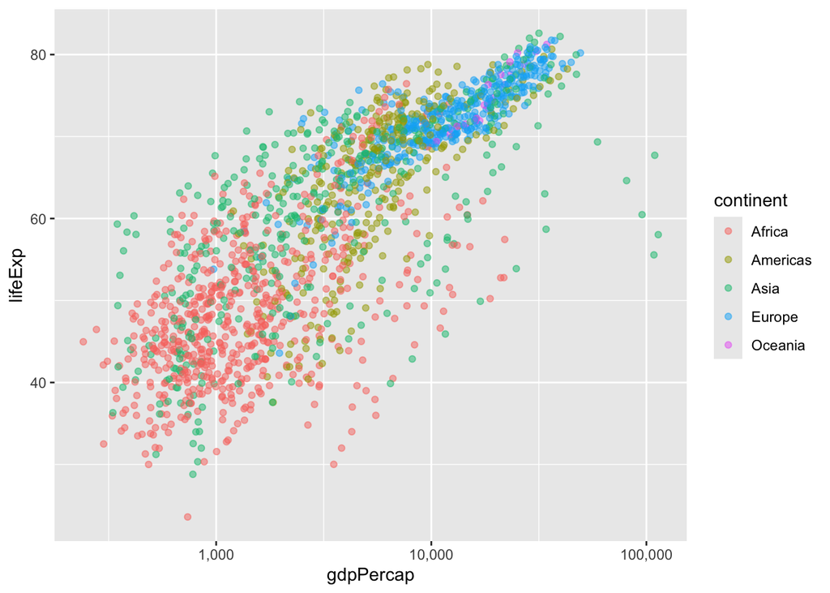

```r
gapminder |>
ggplot(aes(x=gdpPercap, y=lifeExp)) +
  geom_point(aes(color=continent), alpha=0.5) +
  scale_x_log10(labels=label_comma())
```

# 5. Gapminder US Time Series

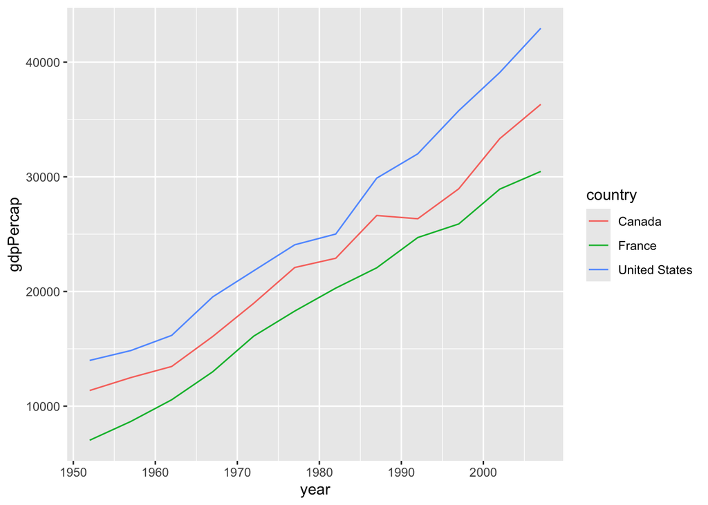

```r
gapminder |>
  filter(country=="United States"|country=="France"|country=="Canada")|>
  ggplot(aes(x=year, y=gdpPercap, color=country)) +
  geom_line()
```

# 6. Explain using Gapminder US Time Series

How has GDP per capita in the U.S. changed over time? What major historical events might explain large shifts?

# In-class excercise: Make a Scatterplot with Percents and Colors

Create a scatterplot with `most_at_home_percent` and `mother_tongue_percent`. Vary the color and shape of the points depending on the category of language. You may need to adjust the position of the legend:

```r
# total population of Canada at time of data collection was 35151728
```